# Introduction to space-time GAMS with `stgam`

Lex Comber, Paul Harris and Chrs Brunsdon

June 2024

## Overview

The aim of this vignette is provide an introduction to the `stgam` package and demonstrates how to construct a spatially vary coefficient (SVC) model and spatial and temporally varying (STVC) model using the `stgam` package. Essentially `stgam` provides a wrapper for constructing GAMs with Gaussian Process (GP) smooths or splines, that are parameterised with location for SVCs and with location and time for STVCs. The key ideas underpinning the development of SVCs with GAMs in the `stgam` package and this vignette are:

1. Standard linear regression assumes that predictor-to-response relationships to be the same throughout the study area.
2. This is often not the case when when location is considered, for example of outliers.
3. Many geographic processes have a Gaussian form when they are examined over 2-dimensional space, as they essentially exhibit distance decay.
4. The GAMs can include smooths or splines of different forms. One such form is a Gaussian Process (GP) spline.
5. GP splines can be specified to model non-linearity (wiggliness) over geographic space if location is included with the covariate.
6. A GAM with GP splines parameterised by location - a Geographic GP GAM or GGP-GAM - defines a spatially varying coefficient (SVC) model.
7. This can be extended to time and space-time.

The approach is presented in outline below, but detail of the SVCs, TVCs and STVCs constructed using GAMs with GP smooths, and the evolution of their application from spatial models to space-time coefficient modelling can be found in Comber, Harris, and Brunsdon (2024) and Comber et al. (submitted). In this, the concept of a Gaussian Process (Wood 2020) is important in the context of regression modelling. It provides a *data model* of the likelihood that a given data set is generated given a statistical model involving some unknown parameters and in regression modelling, the unknown parameters are the regression parameters. These are described formally in Comber, Harris, and Brunsdon (2024) and Comber et al. (submitted).

One final comment is that in this vignette you will all of the varying coefficient models you create assume that spatial, temporal or spatio-temporal dependencies are present in the data. This may not be the case and these assumptions are examined in detail in the second vignette in the `stgam` package.

In this vignette you will:

- Create and interpret a simple SVC using GAMs with GP smooths.
- Create and interpret a simple TVC GAM.
- Extend this to a GP GAM that includes both space and time in smooths to define a STVC model.
- Be encourages to reflect on how space and time interact and the assumptions embedded in the model specification. Be warned! the Vignette only uses one function from the `stgam` package!

## Data and Packagees

You should install the `stgam` package either from CRAN or from GitHub:

```r
install.packages("stgam", dependencies = TRUE)
remotes::install_github("lexcomber/stgam")
```

And then make sure the required packages and data are loaded:

```r
# load the packages
library(stgam)
library(cols4all)   # for nice shading in graphs and maps
library(cowplot)    # for managing plots
library(dplyr)      # for data manipulation
library(ggplot2)    # for plotting and mapping
library(glue)       # for model construction
library(mgcv)       # for GAMs
library(sf)         # for spatial data
library(doParallel) # for parallelising operations
library(purrr)      # for model construction
library(tidyr)      # for model construction
# load the data
data(productivity)
data(us_data)
```

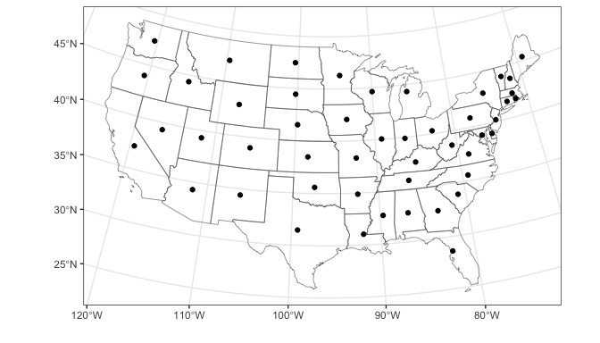

The US States and the geoemtric centroids used as locations.

```r
ggplot() +  geom_sf(data = us_data, fill = NA) +
  geom_point(data = productivity |> filter(year == "1970"), aes(x = X, y = Y)) +
  theme_bw() + ylab("") + xlab("")
```

The data attributes can be examined and a spatial model of constructed using `gam` function from the `mgcv` package. The varying coefficient models created below all focus on Private capital stock (`privC`) as the target variable, with Unemployment (`unemp`) and Public capital (`pubC`) covariates, where the coefficient functions are assumed to be realisation of a Gaussian Process (GP) introduced above.

```r
head(productivity)
```

```
#> # A tibble: 6 × 14
#>   state   GEOID  year region   pubC   hwy water  util  privC   gsp   emp unemp       X
#>   <chr>   <chr> <int> <fct>   <dbl> <dbl> <dbl> <dbl>  <dbl> <int> <dbl> <dbl>   <dbl>
#> 1 ALABAMA 01     1970 6      15033. 7326. 1656. 6051. 35794. 28418 1010.   4.7 858146.
#> 2 ALABAMA 01     1971 6      15502. 7526. 1721. 6255. 37300. 29375 1022.   5.2 858146.
#> 3 ALABAMA 01     1972 6      15972. 7765. 1765. 6442. 38670. 31303 1072.   4.7 858146.
#> 4 ALABAMA 01     1973 6      16406. 7908. 1742. 6756. 40084. 33430 1136.   3.9 858146.
#> 5 ALABAMA 01     1974 6      16763. 8026. 1735. 7002. 42057. 33749 1170.   5.5 858146.
#> 6 ALABAMA 01     1975 6      17316. 8158. 1752. 7406. 43972. 33604 1155.   7.7 858146.
#> # ℹ 1 more variable: Y <dbl>
```

## A simple SVC

A spatially varying coefficient model will be created using the `productivity` dataset.

The code below defines an intercept column (`Intercept`) in the data. This to allow the intercept to be treated as an addressable term in the model. It also defines parametric and non-parametric forms for the intercept and each covariate, so that they can can take a global form (i.e. as in a standard OLS regression) and a spatially varying form in the GP smooth.

```r
# define intercept term
productivity <- productivity |> mutate(Intercept = 1)
# create the SVC
svc.gam = gam(privC ~ 0 +
                Intercept   + s(X, Y, bs = 'gp', by = Intercept) +
                unemp + s(X, Y, bs = "gp", by = unemp) +
                pubC  + s(X, Y, bs = "gp", by = pubC),
              data = productivity |> filter(year == "1970"))
```

- the `<VAR>` is the fixed parametric term for the covariate
- `s(...)` defines the smooth
- `bs = 'gp'` states that this is a GP smooth
- `by = <VAR>` suggests the GP should be multiplied by variable

```r
# check
gam.check(svc.gam)
```

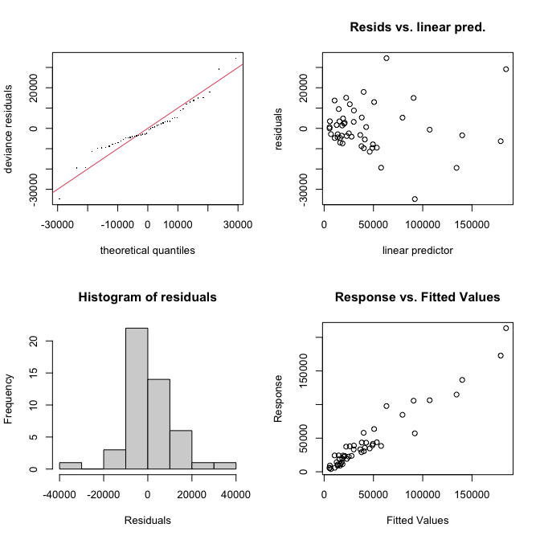

The GAM GP SVC diagnostic plots.

```
#>
#> Method: GCV   Optimizer: magic
#> Smoothing parameter selection converged after 6 iterations by steepest
#> descent step failure.
#> The RMS GCV score gradient at convergence was 2452.878 .
#> The Hessian was not positive definite.
#> Model rank =  8 / 101
#>
#> Basis dimension (k) checking results. Low p-value (k-index<1) may
#> indicate that k is too low, especially if edf is close to k'.
#>
#>                     k'   edf k-index p-value
#> s(X,Y):Intercept 32.00  2.00    0.82   0.065 .
#> s(X,Y):unemp     33.00  2.00    0.82   0.010 **
#> s(X,Y):pubC      33.00  3.67    0.82   0.035 *
#> ---
#> Signif. codes:  0 '***' 0.001 '**' 0.01 '*' 0.05 '.' 0.1 ' ' 1
# model summary
summary(svc.gam)
#>
#> Family: gaussian
#> Link function: identity
#>
#> Formula:
#> privC ~ 0 + Intercept + s(X, Y, bs = "gp", by = Intercept) +
#>     unemp + s(X, Y, bs = "gp", by = unemp) + pubC + s(X, Y, bs = "gp",
#>     by = pubC)
#>
#> Parametric coefficients:
#>             Estimate Std. Error t value Pr(>|t|)
#> Intercept  0.0014245  0.0003432   4.151 0.000168 ***
#> unemp      0.0064540  0.0015548   4.151 0.000168 ***
#> pubC      -3.9243042  0.9571325  -4.100 0.000196 ***
#> ---
#> Signif. codes:  0 '***' 0.001 '**' 0.01 '*' 0.05 '.' 0.1 ' ' 1
#>
#> Approximate significance of smooth terms:
#>                    edf Ref.df       F p-value
#> s(X,Y):Intercept 2.000  2.000   0.453   0.639
#> s(X,Y):unemp     2.000  2.000   0.405   0.676
#> s(X,Y):pubC      3.672  3.715 188.593  <2e-16 ***
#> ---
#> Signif. codes:  0 '***' 0.001 '**' 0.01 '*' 0.05 '.' 0.1 ' ' 1
#>
#> Rank: 8/101
#> R-sq.(adj) =  0.918   Deviance explained = 96.5%
#> GCV = 1.9338e+08  Scale est. = 1.613e+08  n = 48
```

Here it can be seen that:

1. The model is well tuned: all of the all effective degrees of freedom (`edf` are well below `k` in the `gam.check()` printed output (the `k-index<1` issue is not important because of this).
2. All of the the fixed parametric terms are significant.
3. Of the smooth terms, only `pccap` is locally significant and spatially varying.

The spatially varying coefficient estimates can be extracted using `predict`. To do this a dummy data set is created with the `pubC` term set to 1, and the intersect and `unemp` terms set to zero. The result is that the predicted values for the coefficient estimate are just a function of $\beta_2$, the `pubC` coefficient estimate at each location.

```r
get_b2<- productivity |> filter(year == "1970") |> mutate(Intercept = 0, unemp = 0, pubC = 1)
res <- productivity |> filter(year == "1970") |>
  mutate(b2 = predict(svc.gam, newdata = get_b2))
```

The resulting `data.frame` called `res` has a new variable called `b2` which is the spatially varying coefficient estimate for `pubC`. For comparison, we can generate the spatially varying coefficient estimate for the intercept ($\beta_0$) and `unemp` $\beta_1$ (which were not found to be significant locally) in the same way by setting the other terms in the model to zero:

```r
get_b0 <- productivity |> filter(year == "1970") |> mutate(Intercept = 1, unemp = 0, pubC = 0)
res <- res |> mutate(b0 = predict(svc.gam, newdata = get_b0))
get_b1 <- productivity |> filter(year == "1970") |> mutate(Intercept = 0, unemp = 1, pubC = 0)
res <- res |> mutate(b1 = predict(svc.gam, newdata = get_b1))
```

So `res` has the records for the year 1970 and three new columns for `b0`, `b1` and `b2` The distribution of the spatially varying coefficient estimates can be examined:

```r
res |> select(b0, b1, b2) |>
  apply(2, summary) |> round(2)
```

```
#>                b0       b1    b2
#> Min.    -19058.71 -2848.15 -0.18
#> 1st Qu.  -7882.46 -1199.14  1.29
#> Median     731.22  -156.64  2.11
#> Mean         0.00     0.30  2.08
#> 3rd Qu.   7891.22  1179.57  2.85
#> Max.     20699.80  3362.89  3.80
```

The `stgam` package has a function to extract the varying coefficients, `calculate_vcs`. This takes three arguments, the GAM varying coefficient model, the model terms, and the data used to create the model:

```r
terms = c("Intercept", "unemp", "pubC")
res <-  calculate_vcs(model = svc.gam,
                      terms = terms,
                      input_data = productivity |> filter(year == "1970"))
summary(res[, paste0("b_",terms)])
```

```
#>   b_Intercept            b_unemp              b_pubC
#>  Min.   :-19058.713   Min.   :-2848.148   Min.   :-0.1822
#>  1st Qu.: -7882.457   1st Qu.:-1199.142   1st Qu.: 1.2941
#>  Median :   731.222   Median : -156.638   Median : 2.1100
#>  Mean   :     0.001   Mean   :    0.302   Mean   : 2.0825
#>  3rd Qu.:  7891.224   3rd Qu.: 1179.568   3rd Qu.: 2.8474
#>  Max.   : 20699.803   Max.   : 3362.893   Max.   : 3.8034
```

Standard `dplyr` and `ggplot` approaches can be used to join and map the coefficient estimates, formally $\beta_0$, $\beta_1$ and $\beta_2$) as in the figure below. Notice the North-South trend for the Intercept and the East-West and trend for Unemployment - both insignificant predictors of `privC` - and a much stronger specific spatial pattern between the target variable and Public capital (`pubC`), with particularity high coefficient estimates in the south.

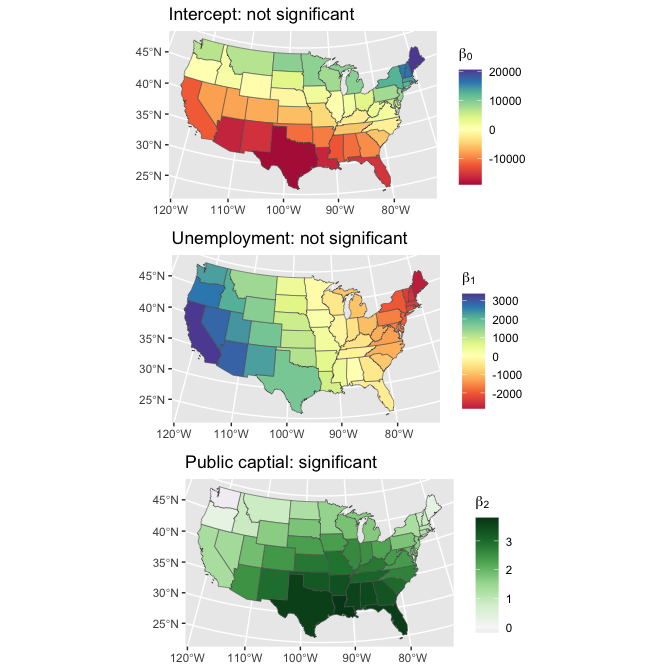

The spatially varying coefficient (SVC) estimates.

```r
# join the data
map_results <-
  us_data |> left_join(res |> select(GEOID, b_Intercept, b_unemp, b_pubC), by = "GEOID")
# plot the insignificant coefficient estimates
tit =expression(paste(""*beta[0]*""))
p1 <-
  ggplot(data = map_results, aes(fill=b_Intercept)) +
  geom_sf() +
  scale_fill_continuous_c4a_div(palette="brewer.spectral",name=tit) +
  coord_sf() +
  ggtitle("Intercept: not significant")
tit =expression(paste(""*beta[1]*""))
p2 <-
  ggplot(data = map_results, aes(fill=b_unemp)) +
  geom_sf() +
  scale_fill_continuous_c4a_div(palette="brewer.spectral",name=tit) +
  coord_sf() +
  ggtitle("Unemployment: not significant")
# plot the significant pubC coefficient estimates
tit =expression(paste(""*beta[2]*" "))
p3 <-
  ggplot(data = map_results, aes(fill=b_pubC)) +
  geom_sf() +
  scale_fill_continuous_c4a_div(palette="brewer.prgn",name=tit) +
  coord_sf() +
  ggtitle("Public captial: significant")
plot_grid(p1, p2, p3, ncol = 1)
```

## A simple TVC

The `productivity` data was filtered for 1970 the the SVC above in which the `X-Y` location of the 48 states was used to parametrise the Gaussian Process smooths. The same structure can be used to create a temporally vary coefficient model (TVC), with smooths specified to include the `year` parameter, but this time not restricting the analysis data to records from a single year:

```r
# create the TVC
tvc.gam = gam(privC ~ 0 +
                Intercept   + s(year, bs = 'gp', by = Intercept) +
                unemp + s(year, bs = "gp", by = unemp) +
                pubC  + s(year, bs = "gp", by = pubC),
              data = productivity)
```

The model can be inspected in the same way to examine the the `k'` and `edf` parameters using the `gam.check` function and again there are no concerns:

```r
gam.check(tvc.gam)
summary(tvc.gam)
```

[output not shown]

The temporally varying coefficients can be extracted in the same way as the DVC approach, explored using the `predict` function and setting each of the covariates to 1 and the others to zero in turn:

```r
terms = c("Intercept", "unemp", "pubC")
res <-  calculate_vcs(model = tvc.gam,
                      terms = terms,
                      input_data = productivity)
summary(res[, paste0("b_",terms)])
```

```
#>   b_Intercept       b_unemp            b_pubC
#>  Min.   :-1057   Min.   :-3733.9   Min.   :1.462
#>  1st Qu.: 7649   1st Qu.:-2342.3   1st Qu.:1.653
#>  Median :16356   Median : -950.6   Median :1.844
#>  Mean   :16356   Mean   : -950.6   Mean   :1.844
#>  3rd Qu.:25063   3rd Qu.:  441.0   3rd Qu.:2.035
#>  Max.   :33769   Max.   : 1832.6   Max.   :2.226
```

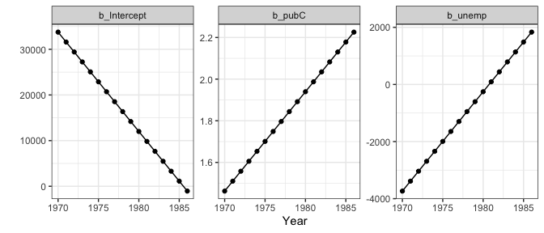

Trends in the temporally varying coefficient estimates.

```r
res |>
  filter(state == "ARIZONA") |>
  select(year, b_Intercept, b_unemp, b_pubC) |>
  pivot_longer(-year) |>
  ggplot(aes(x = year, y = value)) +
  geom_point() + geom_line() +
  facet_wrap(~name, scale = "free") +
  theme_bw() + xlab("Year") + ylab("")
```

## Spatially and Temporally Varying Coefficient (STVC) models

We can combine space and time in GAM GP splines. But how? We could use separate smooths for location and for time, or a single, 3D smooth parameterised with both location and time. There are assumptions associated with each of these. The code below specifies the interaction of the covariates within a single space-time GP smooth. You will notice this takes a few seconds longer to run, and choice of how to specify the smooths is explored in the second vignette in the `stgam` package.

```r
stvc.gam = gam(privC ~ 0 +
                 Intercept   + s(X, Y, year, bs = 'gp', by = Intercept) +
                 unemp + s(X, Y, year, bs = "gp", by = unemp) +
                 pubC  + s(X, Y, year, bs = "gp", by = pubC),
               data = productivity)
```

```r
gam.check(stvc.gam)
summary(stvc.gam)
```

[output not shown]

The coefficients spatial and temporally vary coefficients can be extracted in the same way as before and the variation in coefficient estimates from the STVC-GAM model summarised:

```r
terms = c("Intercept", "unemp", "pubC")
res <-  calculate_vcs(model = stvc.gam,
                      terms = terms,
                      input_data = productivity)
summary(res[, paste0("b_",terms)])
```

```
#>   b_Intercept          b_unemp              b_pubC
#>  Min.   :-9767.27   Min.   :-1581.313   Min.   :0.009162
#>  1st Qu.:-3966.23   1st Qu.: -642.095   1st Qu.:1.619839
#>  Median :  -77.85   Median : -312.564   Median :2.298574
#>  Mean   :    0.00   Mean   :   -2.411   Mean   :2.308127
#>  3rd Qu.: 3378.97   3rd Qu.:  629.192   3rd Qu.:3.027175
#>  Max.   :10806.31   Max.   : 2195.418   Max.   :4.396288
```

This indicates that a positive relationship between Private capital with with Public capital and mixed positive and negative one with Unemployment and the Intercept.

It is instructive to unpick some of the model coefficients in more detail and the code below summarises variations over time through the median values of each coefficient estimate:

```r
res |>
  select(year, b_Intercept, b_unemp, b_pubC) |>
  group_by(year) |>
  summarise(med_b0 = median(b_Intercept),
            med_b1 = median(b_unemp),
            med_b2 = median(b_pubC))
```

```
#> # A tibble: 17 × 4
#>     year med_b0 med_b1 med_b2
#>    <int>  <dbl>  <dbl>  <dbl>
#>  1  1970  -77.8  -313.   1.95
#>  2  1971  -77.8  -313.   1.99
#>  3  1972  -77.8  -313.   2.03
#>  4  1973  -77.8  -313.   2.07
#>  5  1974  -77.8  -313.   2.11
#>  6  1975  -77.8  -313.   2.15
#>  7  1976  -77.8  -313.   2.19
#>  8  1977  -77.8  -313.   2.23
#>  9  1978  -77.8  -313.   2.27
#> 10  1979  -77.8  -313.   2.31
#> 11  1980  -77.8  -313.   2.35
#> 12  1981  -77.8  -313.   2.39
#> 13  1982  -77.8  -313.   2.43
#> 14  1983  -77.8  -313.   2.47
#> 15  1984  -77.8  -313.   2.51
#> 16  1985  -77.8  -313.   2.55
#> 17  1986  -77.8  -313.   2.59
```

It is evident that of the 2 covariates and the intercept used to model Private capital, only Public capital (`b2`) varies (increases) over time. This increase is shown visually below .

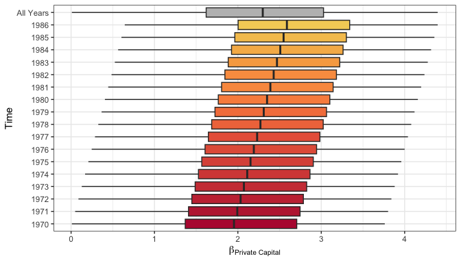

The temporal variation of the Public capital coefficient estimates over 17 years.

```r
# inputs to plot
res |> select(starts_with("b"), year) |>
  mutate(year = "All Years") -> tmp
cols = c(c4a("tableau.red_gold", n = 17, reverse = T), "grey")
tit =expression(paste(""*beta[`Private Capital`]*""))
# plot
res |> select(starts_with("b"), year) |>
  rbind(tmp) |>
  mutate(year = factor(year)) |>
  ggplot(aes(y = year, x = b_pubC, fill = year)) +
  geom_boxplot(outlier.alpha = 0.1) +
  scale_fill_manual(values=cols, guide = "none") +
  theme_bw() + xlab(tit) + ylab("Time")
```

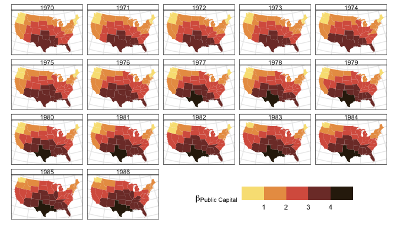

```r
tit =expression(paste(""*beta[`Public Capital`]*""))
# join the data
map_results <-
  us_data |> left_join(res |> select(GEOID, year, b_Intercept, b_unemp, b_pubC), by = "GEOID")
# create the plot
map_results |>
  ggplot() + geom_sf(aes(fill = b_pubC), col = NA) +
    scale_fill_binned_c4a_seq(palette="scico.lajolla", name = tit) +
  facet_wrap(~year) +
    theme_bw() + xlab("") + ylab("") +
    theme(
      strip.background =element_rect(fill="white"),
      strip.text = element_text(size = 8, margin = margin()),
      legend.position = "inside", legend.position.inside = c(0.7, 0.1),
      legend.direction = "horizontal",
      legend.key.width = unit(1, "cm"),
        axis.title.x=element_blank(),
        axis.text.x=element_blank(),
        axis.ticks.x=element_blank(),
        axis.title.y=element_blank(),
        axis.text.y=element_blank(),
        axis.ticks.y=element_blank())
```

## Summary

The rationale for using GAMs with GP splines for spatially varying coefficient (SVC) or temporally varying coefficient (TVC) models is as follows:

- GAMs with splines or smooths capture non-linear relationships between the response variable and covariates.
- splines generate a varying coefficient model when they are parameterised with more than one variable.
- this is readily extending to the temporal and / or spatial dimensions to generate SVCs, TVCs and STVCs.
- different splines are available, but GP splines reflect Tobler’s First Law of Geography (spatial autocorrelation, process spatial heterogeneity, etc).
- this can be extended to the temporal case on the assumption of temporal decay (similarity decreases over time).
- GAMs are robust, have a rich theoretical background and been subject to much development.

Initial research has demonstrated the formulation and application of a GAM with GP splines calibrated via observation location as a multiscale SVC model: the Geographical Gaussian Process GAM (GGP-GAM) (Comber, Harris, and Brunsdon 2024). The GGP-GAM was compared with the most popular SVC model, Geographically Weighted Regression (GWR) (Brunsdon, Fotheringham, and Charlton 1996) and shown to out-perform Multiscale GWR.

However, when handling space *and* time, simply plugging all the space time data into specific GAM configuration is to make potentially unreasonable assumptions about how space and time interact in spatially and temporally varying coefficient (STVC) models. To address this workshop has suggested that the full set of models is investigated to identify the best model or the best set of models. Where there is a clear winner, this can be applied. Where these is not, as in the example used then the model coefficients can be combined using Bayesian Model Averaging (in the second vignette).

## References

Bivand, Roger, Jakub Nowosad, and Robin Lovelace. 2019. “spData: Datasets for Spatial Analysis.” R package version 0.3. 0, URL https://CRAN. R-project. org/package= spData.

Brunsdon, Chris, A Stewart Fotheringham, and Martin E Charlton. 1996. “Geographically Weighted Regression: A Method for Exploring Spatial Nonstationarity.” *Geographical Analysis* 28 (4): 281–98.

Comber, Alexis, Paul Harris, and Chris Brunsdon. 2024. “Multiscale Spatially Varying Coefficient Modelling Using a Geographical Gaussian Process GAM.” *International Journal of Geographical Information Science* 38 (1): 27–47.

Comber, Alexis, Paul Harris, Naru Tsutsumida, Jennie Gray, and Chris Brunsdon. submitted. “Where, When and How? Specifying Spatially and Temporally Varying Coefficient Models Using Generalized Additive Models with Gaussian Process Splines.” *International Journal of Geographical Information Science*, submitted.

Croissant, Yves, Giovanni Millo, and Kevin Tappe. 2022. “Plm: Linear Models for Panel Data.”

Wood, Simon N. 2020. “Inference and Computation with Generalized Additive Models and Their Extensions.” *TEST* 29 (2): 307–39. https://doi.org/10.1007/s11749-020-00711-5.